# Probability Theory, Distributions, and Summary Statistics

Experimental Design and Biostatistics Course

Francisco E. Fontúrbel

2026-04-10

```r
# Required libraries
library(ggplot2)
library(dplyr)
library(tidyr)
library(patchwork)
library(moments)    # skewness, kurtosis
library(MASS)       # fitdistr

# General theme for figures
theme_set(
  theme_bw(base_size = 13) +
    theme(
      panel.grid.minor = element_blank(),
      strip.background = element_rect(fill = "grey90")
    )
)

# Seed for reproducibility
set.seed(2025)
```

# 1 Axioms and Probability Theory

## 1.1 Random experiments and the sample space

In ecology we constantly deal with phenomena whose outcome cannot be predicted with certainty: will a pollinator visit a flower in the next 10 minutes? How many *Tristerix corymbosus* seeds will be dispersed by *Dromiciops gliroides* in a single night? These are **random experiments**.

Key definitions:

- **Random experiment** ($\mathcal{E}$): a process whose outcome cannot be predicted with certainty.
- **Sample space** ($\Omega$): the set of all possible outcomes.
- **Event** ($A \subseteq \Omega$): a subset of the sample space.

**Ecological example:** We observe a ripe fruit of *T. corymbosus* and record whether it is removed by a frugivorous bird within 1 hour.

$$\Omega = \{\text{removed}, \text{not
removed}\}$$

If we observe 3 fruits simultaneously:

$$\Omega = \{(r, r, r),\ (r, r, n),\ (r,
n, r),\ \ldots,\ (n, n, n)\}, \quad |\Omega| = 2^3 = 8$$

## 1.2 Kolmogorov’s Axioms (1933)

Let $\Omega$ be a sample space and $\mathcal{F}$ a $\sigma$-algebra of events. A **probability function** $P: \mathcal{F} \rightarrow [0, 1]$ satisfies:

1. **Non-negativity:** $P(A) \geq 0$ for all $A \in \mathcal{F}$.
2. **Normalization:** $P(\Omega) = 1$.
3. **Countable additivity:** If $A_1, A_2, \ldots$ are mutually exclusive:

$$P\left(\bigcup_{i=1}^{\infty} A_i\right)
= \sum_{i=1}^{\infty} P(A_i)$$

In plain words: (1) probabilities are never negative, (2) the probability that *something* happens is 1, and (3) if two or more events cannot occur simultaneously, the probability that at least one of them occurs is simply the sum of their individual probabilities. All of probability theory is built from these three rules.

### 1.2.1 Direct consequences

From these three axioms, key properties follow:

- $P(\emptyset) = 0$ — the impossible event has probability zero.
- $P(A^c) = 1 - P(A)$ — the probability that an event does *not* occur is the complement of it occurring.
- If $A \subseteq B$, then $P(A) \leq P(B)$ — an event contained within another cannot be more probable than the latter.
- $P(A \cup B) = P(A) + P(B) - P(A \cap B)$ — the addition rule: when summing the probabilities of two events, we must subtract their intersection to avoid counting it twice.

```r
# Simulation: pollinator visitation probability
# Suppose we observe a plant during 100 intervals of 10 min each

n_intervals <- 100
p_visit_bee <- 0.35
p_visit_hummingbird <- 0.15
p_both <- 0.05  # simultaneous visit

# Addition rule
p_at_least_one <- p_visit_bee + p_visit_hummingbird - p_both

cat("P(bee visit) =", p_visit_bee, "\n")
```

```
#> P(bee visit) = 0.35
```

```r
cat("P(hummingbird visit) =", p_visit_hummingbird, "\n")
```

```
#> P(hummingbird visit) = 0.15
```

```r
cat("P(both) =", p_both, "\n")
```

```
#> P(both) = 0.05
```

```r
cat("P(at least one pollinator) =", p_at_least_one, "\n")
```

```
#> P(at least one pollinator) = 0.45
```

```r
cat("P(no pollinator) =", 1 - p_at_least_one, "\n")
```

```
#> P(no pollinator) = 0.55
```

## 1.3 Conditional probability

The probability of an event $A$ given that $B$ has occurred:

$$P(A \mid B) = \frac{P(A \cap B)}{P(B)},
\quad P(B) > 0$$

That is, if we already know that $B$ occurred, the probability of $A$ is recalculated considering only those cases where both events happen together, divided by the probability of $B$. Intuitively, conditioning means “shrinking the universe” to the subset where $B$ has already taken place.

**Ecological example:** In a temperate forest, the probability of detecting *D. gliroides* on a camera trap depends on habitat type.

```r
# Hypothetical detection data for D. gliroides
# Based on typical proportions from camera trap studies

n_nights <- 200

# Contingency table
detection <- matrix(
  c(42, 58, 12, 88),
  nrow = 2, byrow = TRUE,
  dimnames = list(
    Habitat = c("Native forest", "Eucalyptus plantation"),
    Detection = c("Detected", "Not detected")
  )
)

detection
```

```
#>                        Detection
#> Habitat                 Detected Not detected
#>   Native forest               42           58
#>   Eucalyptus plantation       12           88
```

```r
# P(Detected | Native forest)
p_det_native <- detection["Native forest", "Detected"] /
  sum(detection["Native forest", ])

# P(Detected | Plantation)
p_det_plant <- detection["Eucalyptus plantation", "Detected"] /
  sum(detection["Eucalyptus plantation", ])

cat("P(Detection | Native forest) =", round(p_det_native, 3), "\n")
```

```
#> P(Detection | Native forest) = 0.42
```

```r
cat("P(Detection | Plantation) =", round(p_det_plant, 3), "\n")
```

```
#> P(Detection | Plantation) = 0.12
```

```r
cat("Detection ratio native/plantation =",
    round(p_det_native / p_det_plant, 2), "\n")
```

```
#> Detection ratio native/plantation = 3.5
```

## 1.4 Bayes’ Theorem

$$P(A \mid B) = \frac{P(B \mid A) \cdot
P(A)}{P(B)}$$

Where $P(B)$ can be expanded using the **law of total probability**:

$$P(B) = \sum_{i=1}^{n} P(B \mid A_i)
\cdot P(A_i)$$

Bayes’ theorem allows us to “invert” the direction of a conditional probability: if we know the probability of observing certain evidence given each possible cause, we can calculate the probability of each cause given that we observed the evidence. The denominator $P(B)$ acts as a normalization factor obtained by summing over all possible causes.

### 1.4.1 Application: identifying seed dispersers

Suppose we find a germinating seed of *T. corymbosus* on a branch. What is the probability that it was deposited by *D. gliroides* versus a frugivorous bird?

```r
# Data based on the literature
p_dromiciops <- 0.30    # P(disperser = D. gliroides)
p_bird <- 0.70          # P(disperser = bird)

# P(viable seed | disperser)
p_viable_dromiciops <- 0.85   # D. gliroides: high viability
p_viable_bird <- 0.40         # Birds: moderate viability

# P(viable seed) - total probability
p_viable <- p_viable_dromiciops * p_dromiciops +
  p_viable_bird * p_bird

# P(D. gliroides | viable seed) - Bayes
p_dromiciops_given_viable <- (p_viable_dromiciops * p_dromiciops) / p_viable

cat("P(viable seed) =", round(p_viable, 3), "\n")
```

```
#> P(viable seed) = 0.535
```

```r
cat("P(D. gliroides | viable seed) =",
    round(p_dromiciops_given_viable, 3), "\n")
```

```
#> P(D. gliroides | viable seed) = 0.477
```

```r
cat("P(bird | viable seed) =",
    round(1 - p_dromiciops_given_viable, 3), "\n")
```

```
#> P(bird | viable seed) = 0.523
```

> **Interpretation:** Although birds account for 70% of seed dispersal, if we find a viable seed, the probability that it came from *D. gliroides* is 47.7%. This reflects the greater effectiveness of this marsupial as a legitimate seed disperser.

## 1.5 Independence

Two events $A$ and $B$ are **independent** if and only if:

$$P(A \cap B) = P(A) \cdot
P(B)$$

Equivalently: $P(A \mid B) = P(A)$.

In simple terms, two events are independent when knowing that one occurred does not change the probability of the other in any way. Under independence, the joint probability is simply the product of the marginal probabilities.

In ecology, independence is a **strong assumption** that is rarely met. Spatial, temporal, and phylogenetic dependence are the norm in ecological data.

```r
# Independence test: pollinator visits
# Are bee and hummingbird visits to Tristerix independent?

# Simulated visit data for 150 flowers
set.seed(42)
n_flowers <- 150

visits <- data.frame(
  bee = rbinom(n_flowers, 1, prob = 0.40),
  hummingbird = rbinom(n_flowers, 1, prob = 0.25)
)

# Introduce negative dependence (resource competition)
# If the bee visited, we reduce P(hummingbird)
for (i in 1:n_flowers) {
  if (visits$bee[i] == 1) {
    visits$hummingbird[i] <- rbinom(1, 1, prob = 0.10)
  }
}

tab <- table(
  Bee = ifelse(visits$bee == 1, "Yes", "No"),
  Hummingbird = ifelse(visits$hummingbird == 1, "Yes", "No")
)

tab
```

```
#>      Hummingbird
#> Bee   No Yes
#>   No  58  20
#>   Yes 60  12
```

```r
# Chi-squared test of independence
chi_test <- chisq.test(tab)
chi_test
```

```
#>
#>  Pearson's Chi-squared test with Yates' continuity correction
#>
#> data:  tab
#> X-squared = 1.3018, df = 1, p-value = 0.2539
```

```r
cat("Under independence, P(hummingbird | bee) should be approx. P(hummingbird)\n")
```

```
#> Under independence, P(hummingbird | bee) should be approx. P(hummingbird)
```

```r
cat("P(hummingbird) =", round(mean(visits$hummingbird), 3), "\n")
```

```
#> P(hummingbird) = 0.213
```

```r
cat("P(hummingbird | bee visited) =",
    round(mean(visits$hummingbird[visits$bee == 1]), 3), "\n")
```

```
#> P(hummingbird | bee visited) = 0.167
```

```r
cat("P(hummingbird | bee did not visit) =",
    round(mean(visits$hummingbird[visits$bee == 0]), 3), "\n")
```

```
#> P(hummingbird | bee did not visit) = 0.256
```

## 1.6 Non-independent probabilities: Markov chains and Monte Carlo methods

In the previous section we saw that independence is the exception in ecology. In practice, the current state of a system usually depends on its previous state: patch occupancy this year depends on whether it was occupied last year, the probability that an animal moves to a site depends on where it currently is, and community composition depends on its assembly history. To model this type of sequential dependence, we use **Markov chains**.

### 1.6.1 Markov chains

A Markov chain is a stochastic process where the probability of transitioning to the next state depends **solely on the current state**, not on the full history. This is the **Markov property** (or “memorylessness”):

$$P(X_{t+1} = j \mid X_t = i, X_{t-1},
\ldots, X_0) = P(X_{t+1} = j \mid X_t = i)$$

In other words, if we know the present, the past provides no additional information for predicting the future. The full dynamics of the system are described by a **transition matrix** $\mathbf{T}$, where each element $T_{ij}$ represents the probability of moving from state $i$ to state $j$ in one time step.

**Ecological example:** Patch occupancy model for *D. gliroides* with three states: occupied patch (O), empty available patch (V), and degraded patch (D).

```r
# Transition matrix for patch occupancy
# Rows = current state, Columns = next state
T_mat <- matrix(
  c(0.75, 0.15, 0.10,   # From Occupied: stays, empties, degrades
    0.30, 0.50, 0.20,   # From Empty: colonized, stays, degrades
    0.05, 0.25, 0.70),  # From Degraded: recovers, improves, stays
  nrow = 3, byrow = TRUE,
  dimnames = list(
    From = c("Occupied", "Empty", "Degraded"),
    To = c("Occupied", "Empty", "Degraded")
  )
)

knitr::kable(T_mat, digits = 2,
             caption = "Transition matrix: habitat patch dynamics")
```

Transition matrix: habitat patch dynamics

|  | Occupied | Empty | Degraded |
| --- | --- | --- | --- |
| Occupied | 0.75 | 0.15 | 0.1 |
| Empty | 0.30 | 0.50 | 0.2 |
| Degraded | 0.05 | 0.25 | 0.7 |

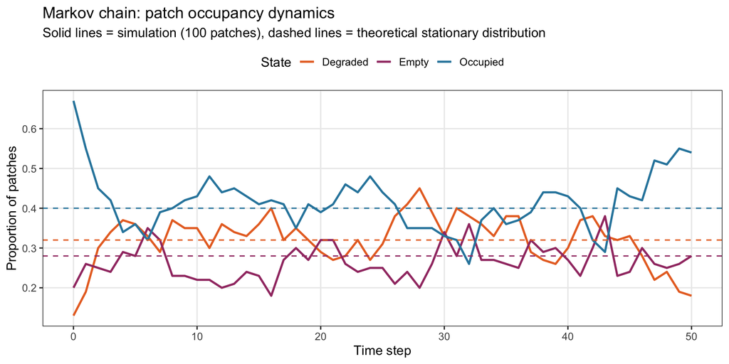

```r
# Markov chain simulation for 50 time steps
n_steps <- 50
n_patches <- 100
states <- c("Occupied", "Empty", "Degraded")

# Initial state: 60% occupied, 25% empty, 15% degraded
current_state <- sample(states, n_patches, replace = TRUE,
                        prob = c(0.60, 0.25, 0.15))

# Record proportions over time
record <- matrix(NA, nrow = n_steps + 1, ncol = 3,
                 dimnames = list(NULL, states))
record[1, ] <- table(factor(current_state, levels = states)) / n_patches

set.seed(2025)
for (t in 1:n_steps) {
  new_state <- character(n_patches)
  for (i in 1:n_patches) {
    row_idx <- match(current_state[i], states)
    new_state[i] <- sample(states, 1, prob = T_mat[row_idx, ])
  }
  current_state <- new_state
  record[t + 1, ] <- table(factor(current_state, levels = states)) / n_patches
}

# Theoretical stationary distribution (left eigenvector of T)
eigv <- eigen(t(T_mat))
pi_stat <- Re(eigv$vectors[, 1])
pi_stat <- pi_stat / sum(pi_stat)
names(pi_stat) <- states

# Plot
df_markov <- data.frame(
  step = rep(0:n_steps, 3),
  proportion = c(record[, 1], record[, 2], record[, 3]),
  state = rep(states, each = n_steps + 1)
)

ggplot(df_markov, aes(x = step, y = proportion, color = state)) +
  geom_line(linewidth = 1) +
  geom_hline(data = data.frame(state = states, y = pi_stat),
             aes(yintercept = y, color = state),
             linetype = "dashed", linewidth = 0.6) +
  scale_color_manual(values = c("Degraded" = "#E8702A",
                                "Occupied" = "#2E86AB",
                                "Empty" = "#A23B72")) +
  labs(
    title = "Markov chain: patch occupancy dynamics",
    subtitle = "Solid lines = simulation (100 patches), dashed lines = theoretical stationary distribution",
    x = "Time step", y = "Proportion of patches",
    color = "State"
  ) +
  theme(legend.position = "top")
```

```r
cat("Stationary distribution (pi):\n")
```

```
#> Stationary distribution (pi):
```

```r
cat(paste0("  ", states, ": ", round(pi_stat, 3), collapse = "\n"), "\n\n")
```

```
#>   Occupied: 0.4
#>   Empty: 0.28
#>   Degraded: 0.32
```

```r
cat("In the long run, regardless of the initial state, the system converges\n")
```

```
#> In the long run, regardless of the initial state, the system converges
```

```r
cat("to these equilibrium proportions.\n")
```

```
#> to these equilibrium proportions.
```

A fundamental property of ergodic Markov chains (irreducible and aperiodic) is that they converge to a **stationary distribution** $\boldsymbol{\pi}$ that does not depend on the initial state. This is precisely what Monte Carlo methods exploit.

### 1.6.2 Markov chain Monte Carlo methods (MCMC)

**MCMC** methods combine Markov chains with Monte Carlo sampling to draw samples from complex probability distributions, typically Bayesian posterior distributions that lack an analytical solution.

The key idea is to construct a Markov chain whose stationary distribution is exactly the target distribution $p(\theta \mid \text{data})$. By running the chain long enough, the generated samples are representative of the posterior distribution, and we can use them to estimate parameters, credible intervals, and make predictions.

The most commonly used algorithms are:

- **Metropolis-Hastings**: proposes a random jump and accepts or rejects it based on a probability ratio. It is general-purpose but can be slow in high-dimensional spaces.
- **Gibbs sampling**: a special case where the full conditional distributions of each parameter are sampled in turn. It is efficient when those conditionals have a known form.
- **Hamiltonian Monte Carlo (HMC)**: uses gradient information to propose more efficient jumps. It is the engine behind Stan and `brms`.

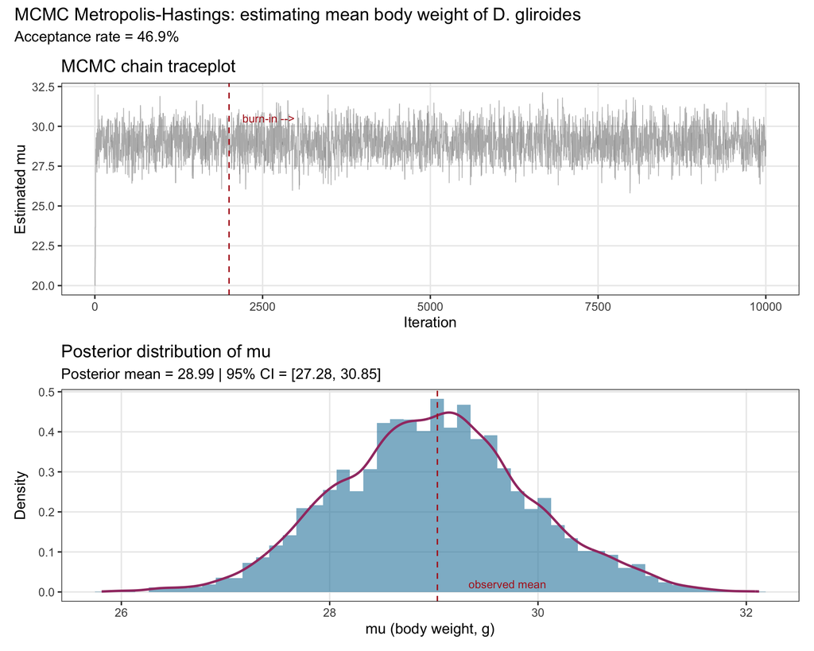

```r
# Simplified Metropolis-Hastings demonstration
# Estimating mean body weight of D. gliroides
# Assuming prior Normal(25, 10) and likelihood Normal(mu, sigma=5)

set.seed(2025)
obs_weight_data <- rnorm(30, mean = 28, sd = 5)  # observed data

# Functions
log_posterior <- function(mu, data, prior_mu = 25, prior_sd = 10, sigma = 5) {
  log_lik <- sum(dnorm(data, mean = mu, sd = sigma, log = TRUE))
  log_prior <- dnorm(mu, mean = prior_mu, sd = prior_sd, log = TRUE)
  log_lik + log_prior
}

# Metropolis-Hastings
n_iter <- 10000
chain <- numeric(n_iter)
chain[1] <- 20  # starting value far from the optimum
proposal_sd <- 2
accepted <- 0

for (i in 2:n_iter) {
  proposal <- rnorm(1, mean = chain[i - 1], sd = proposal_sd)
  log_ratio <- log_posterior(proposal, obs_weight_data) -
    log_posterior(chain[i - 1], obs_weight_data)

  if (log(runif(1)) < log_ratio) {
    chain[i] <- proposal
    accepted <- accepted + 1
  } else {
    chain[i] <- chain[i - 1]
  }
}

# Discard burn-in
burnin <- 2000
post_samples <- chain[(burnin + 1):n_iter]

# Diagnostic plots
df_chain <- data.frame(
  iteration = 1:n_iter,
  mu = chain
)

p_trace <- ggplot(df_chain, aes(iteration, mu)) +
  geom_line(alpha = 0.5, color = "grey40", linewidth = 0.3) +
  geom_vline(xintercept = burnin, linetype = "dashed",
             color = "firebrick", linewidth = 0.6) +
  annotate("text", x = burnin + 200, y = max(chain) * 0.95,
           label = "burn-in -->", color = "firebrick", hjust = 0, size = 3.5) +
  labs(title = "MCMC chain traceplot",
       x = "Iteration", y = "Estimated mu")

p_post <- ggplot(data.frame(mu = post_samples), aes(mu)) +
  geom_histogram(aes(y = after_stat(density)),
                 bins = 50, fill = "#2E86AB", alpha = 0.6) +
  geom_density(color = "#A23B72", linewidth = 1) +
  geom_vline(xintercept = mean(obs_weight_data),
             linetype = "dashed", color = "firebrick") +
  annotate("text", x = mean(obs_weight_data) + 0.3,
           y = 0, label = "observed mean",
           color = "firebrick", hjust = 0, vjust = -0.5, size = 3.5) +
  labs(title = "Posterior distribution of mu",
       subtitle = paste0("Posterior mean = ",
                         round(mean(post_samples), 2),
                         " | 95% CI = [",
                         round(quantile(post_samples, 0.025), 2), ", ",
                         round(quantile(post_samples, 0.975), 2), "]"),
       x = "mu (body weight, g)", y = "Density")

p_trace / p_post +
  plot_annotation(
    title = "MCMC Metropolis-Hastings: estimating mean body weight of D. gliroides",
    subtitle = paste0("Acceptance rate = ",
                      round(accepted / n_iter * 100, 1), "%")
  )
```

```r
cat("Posterior distribution summary:\n")
```

```
#> Posterior distribution summary:
```

```r
cat("  Posterior mean:", round(mean(post_samples), 3), "\n")
```

```
#>   Posterior mean: 28.991
```

```r
cat("  Posterior median:", round(median(post_samples), 3), "\n")
```

```
#>   Posterior median: 28.996
```

```r
cat("  Posterior SD:", round(sd(post_samples), 3), "\n")
```

```
#>   Posterior SD: 0.912
```

```r
cat("  95% CI: [", round(quantile(post_samples, 0.025), 3), ",",
    round(quantile(post_samples, 0.975), 3), "]\n")
```

```
#>   95% CI: [ 27.276 , 30.851 ]
```

```r
cat("  Acceptance rate:", round(accepted / n_iter * 100, 1), "%\n\n")
```

```
#>   Acceptance rate: 46.9 %
```

```r
cat("Note: an acceptance rate between 20-50% is generally\n")
```

```
#> Note: an acceptance rate between 20-50% is generally
```

```r
cat("desirable for one-dimensional Metropolis-Hastings.\n")
```

```
#> desirable for one-dimensional Metropolis-Hastings.
```

> **Why does this matter for ecologists?** MCMC is the computational engine behind the Bayesian models we use routinely: `MCMCglmm`, `brms`, `JAGS`, `Stan`, and occupancy models (`unmarked`, `ubms`). Every time we fit one of these models, a Markov chain is running internally that converges to the posterior distribution of the parameters. Understanding these foundations allows us to diagnose convergence issues and correctly interpret our results.

# 2 Probability Distributions

## 2.1 Random variables

A **random variable** $X$ is a function that assigns a numerical value to each outcome in the sample space: $X: \Omega \rightarrow \mathbb{R}$.

- **Discrete:** takes countable values (individual counts, number of seeds).
- **Continuous:** takes any value in an interval (biomass, body length, temperature).

## 2.2 Discrete distributions

### 2.2.1 Bernoulli and Binomial

If each trial has probability $p$ of success, and we perform $n$ independent trials:

$$X \sim \text{Binomial}(n, p), \quad P(X
= k) = \binom{n}{k} p^k (1-p)^{n-k}$$

- $E[X] = np$
- $\text{Var}(X) = np(1-p)$

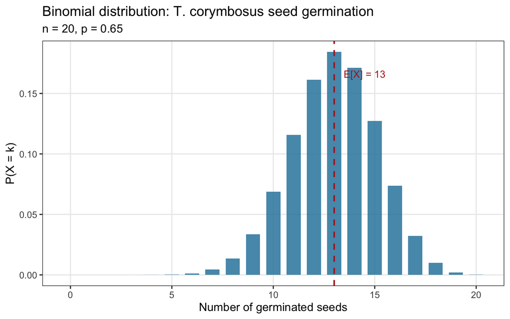

```r
# Example: seed germination of T. corymbosus
# Experiment: 20 seeds, P(germination) = 0.65

n_seeds <- 20
p_germ <- 0.65
x <- 0:n_seeds

prob_binom <- dbinom(x, size = n_seeds, prob = p_germ)

p1 <- ggplot(data.frame(x, prob = prob_binom), aes(x, prob)) +
  geom_col(fill = "#2E86AB", width = 0.7, alpha = 0.85) +
  geom_vline(xintercept = n_seeds * p_germ,
             linetype = "dashed", color = "firebrick", linewidth = 0.8) +
  annotate("text", x = n_seeds * p_germ + 1.5,
           y = max(prob_binom) * 0.9,
           label = paste0("E[X] = ", n_seeds * p_germ),
           color = "firebrick", size = 4) +
  labs(
    title = "Binomial distribution: T. corymbosus seed germination",
    subtitle = paste0("n = ", n_seeds, ", p = ", p_germ),
    x = "Number of germinated seeds",
    y = "P(X = k)"
  )

p1
```

### 2.2.2 Poisson

Models counts of rare events in a fixed interval. If $\lambda$ is the mean rate:

$$X \sim \text{Poisson}(\lambda), \quad
P(X = k) = \frac{e^{-\lambda} \lambda^k}{k!}$$

- $E[X] = \lambda$
- $\text{Var}(X) = \lambda$ (equidispersion)

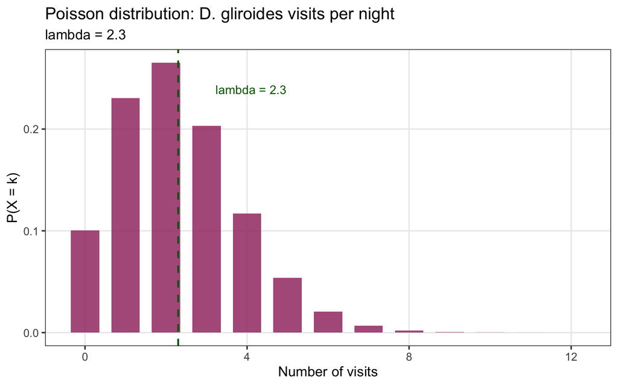

```r
# Example: D. gliroides visit counts per camera trap per night
lambda_visits <- 2.3
x_pois <- 0:12

prob_pois <- dpois(x_pois, lambda = lambda_visits)

p2 <- ggplot(data.frame(x = x_pois, prob = prob_pois), aes(x, prob)) +
  geom_col(fill = "#A23B72", width = 0.7, alpha = 0.85) +
  geom_vline(xintercept = lambda_visits,
             linetype = "dashed", color = "darkgreen", linewidth = 0.8) +
  annotate("text", x = lambda_visits + 1.8,
           y = max(prob_pois) * 0.9,
           label = paste0("lambda = ", lambda_visits),
           color = "darkgreen", size = 4) +
  labs(
    title = "Poisson distribution: D. gliroides visits per night",
    subtitle = paste0("lambda = ", lambda_visits),
    x = "Number of visits",
    y = "P(X = k)"
  )

p2
```

### 2.2.3 Negative Binomial

When there is **overdispersion** ($\text{Var}(X) > E[X]$), the Poisson is inadequate. The negative binomial adds a dispersion parameter $\theta$ (or $k$):

$$\text{Var}(X) = \mu +
\frac{\mu^2}{\theta}$$

As $\theta \rightarrow \infty$, it converges to the Poisson.

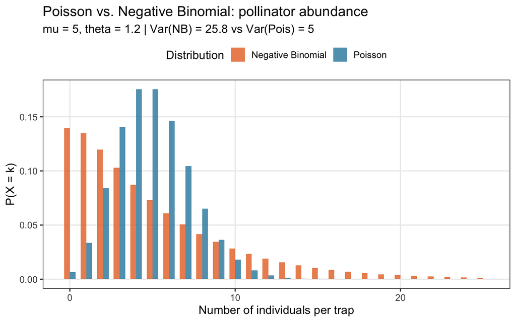

```r
# Example: pollinating insect abundance per trap (overdispersion)
mu_insects <- 5
theta_val <- 1.2  # strong overdispersion

x_nb <- 0:25

prob_nb <- dnbinom(x_nb, mu = mu_insects, size = theta_val)
prob_pois_comp <- dpois(x_nb, lambda = mu_insects)

df_comp <- data.frame(
  x = rep(x_nb, 2),
  prob = c(prob_nb, prob_pois_comp),
  Distribution = rep(c("Negative Binomial", "Poisson"), each = length(x_nb))
)

p3 <- ggplot(df_comp, aes(x, prob, fill = Distribution)) +
  geom_col(position = "dodge", width = 0.7, alpha = 0.8) +
  scale_fill_manual(values = c("#E8702A", "#2E86AB")) +
  labs(
    title = "Poisson vs. Negative Binomial: pollinator abundance",
    subtitle = paste0("mu = ", mu_insects,
                      ", theta = ", theta_val,
                      " | Var(NB) = ",
                      round(mu_insects + mu_insects^2 / theta_val, 1),
                      " vs Var(Pois) = ", mu_insects),
    x = "Number of individuals per trap",
    y = "P(X = k)"
  ) +
  theme(legend.position = "top")

p3
```

> **Note for ecologists:** Overdispersion is *the rule* in ecological abundance data. Always evaluate the mean-variance relationship before assuming Poisson. The `glm.nb()` function from `MASS` or `glmmTMB()` are robust alternatives.

## 2.3 Continuous distributions

### 2.3.1 Normal (Gaussian)

$$X \sim \mathcal{N}(\mu, \sigma^2), \quad
f(x) = \frac{1}{\sigma\sqrt{2\pi}}
\exp\left(-\frac{(x-\mu)^2}{2\sigma^2}\right)$$

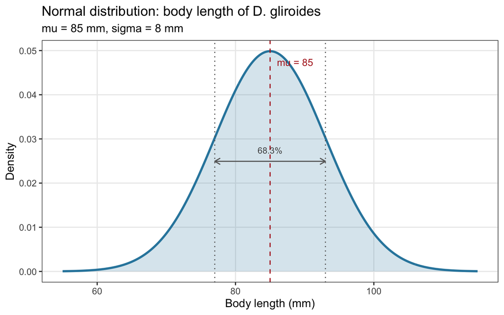

```r
# Example: body length of D. gliroides (mm)
mu_bl <- 85    # mean in mm
sigma_bl <- 8  # standard deviation

x_norm <- seq(55, 115, length.out = 300)

df_norm <- data.frame(
  x = x_norm,
  density = dnorm(x_norm, mean = mu_bl, sd = sigma_bl)
)

p4 <- ggplot(df_norm, aes(x, density)) +
  geom_line(color = "#2E86AB", linewidth = 1.2) +
  geom_area(alpha = 0.2, fill = "#2E86AB") +
  geom_vline(xintercept = mu_bl, linetype = "dashed", color = "firebrick") +
  geom_vline(xintercept = c(mu_bl - sigma_bl, mu_bl + sigma_bl),
             linetype = "dotted", color = "grey40") +
  annotate("text", x = mu_bl + 1, y = max(df_norm$density) * 0.95,
           label = paste0("mu = ", mu_bl), color = "firebrick",
           hjust = 0, size = 4) +
  annotate("segment",
           x = mu_bl - sigma_bl, xend = mu_bl + sigma_bl,
           y = max(df_norm$density) * 0.5,
           yend = max(df_norm$density) * 0.5,
           arrow = arrow(ends = "both", length = unit(0.1, "inches")),
           color = "grey40") +
  annotate("text", x = mu_bl, y = max(df_norm$density) * 0.55,
           label = "68.3%", color = "grey30", size = 3.5) +
  labs(
    title = "Normal distribution: body length of D. gliroides",
    subtitle = paste0("mu = ", mu_bl, " mm, sigma = ", sigma_bl, " mm"),
    x = "Body length (mm)",
    y = "Density"
  )

p4
```

### 2.3.2 Log-Normal

If $\ln(X) \sim \mathcal{N}(\mu, \sigma^2)$, then $X$ follows a log-normal distribution. Very common in ecology for positive variables with right skewness (biomass, range area, population size).

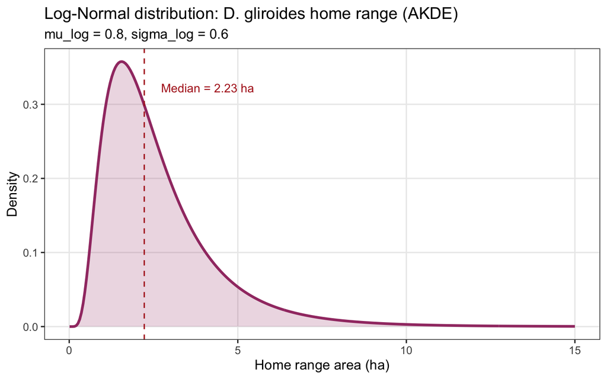

```r
# Example: home range area of D. gliroides (ha) estimated by AKDE
mu_log <- 0.8
sigma_log <- 0.6

x_ln <- seq(0.01, 15, length.out = 300)

df_ln <- data.frame(
  x = x_ln,
  density = dlnorm(x_ln, meanlog = mu_log, sdlog = sigma_log)
)

p5 <- ggplot(df_ln, aes(x, density)) +
  geom_line(color = "#A23B72", linewidth = 1.2) +
  geom_area(alpha = 0.2, fill = "#A23B72") +
  geom_vline(xintercept = exp(mu_log), linetype = "dashed",
             color = "firebrick") +
  annotate("text", x = exp(mu_log) + 0.5,
           y = max(df_ln$density) * 0.9,
           label = paste0("Median = ", round(exp(mu_log), 2), " ha"),
           color = "firebrick", hjust = 0, size = 4) +
  labs(
    title = "Log-Normal distribution: D. gliroides home range (AKDE)",
    subtitle = paste0("mu_log = ", mu_log, ", sigma_log = ", sigma_log),
    x = "Home range area (ha)",
    y = "Density"
  )

p5
```

### 2.3.3 Gamma

Useful for modeling waiting times or positive continuous variables with variable skewness:

$$X \sim \text{Gamma}(\alpha, \beta),
\quad E[X] = \alpha/\beta, \quad \text{Var}(X) =
\alpha/\beta^2$$

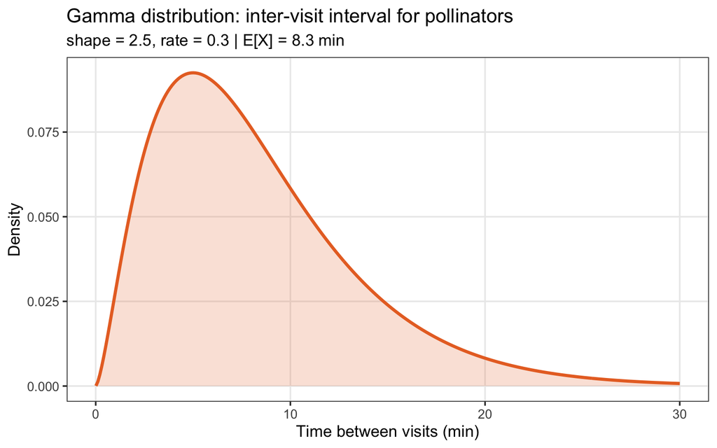

```r
# Example: time between successive pollinator visits (minutes)
shape_val <- 2.5
rate_val <- 0.3

x_gam <- seq(0.01, 30, length.out = 300)

df_gam <- data.frame(
  x = x_gam,
  density = dgamma(x_gam, shape = shape_val, rate = rate_val)
)

p6 <- ggplot(df_gam, aes(x, density)) +
  geom_line(color = "#E8702A", linewidth = 1.2) +
  geom_area(alpha = 0.2, fill = "#E8702A") +
  labs(
    title = "Gamma distribution: inter-visit interval for pollinators",
    subtitle = paste0("shape = ", shape_val, ", rate = ", rate_val,
                      " | E[X] = ", round(shape_val / rate_val, 1), " min"),
    x = "Time between visits (min)",
    y = "Density"
  )

p6
```

### 2.3.4 Beta

Models proportions and probabilities ($X \in [0, 1]$):

$$X \sim \text{Beta}(\alpha, \beta), \quad
E[X] = \frac{\alpha}{\alpha + \beta}$$

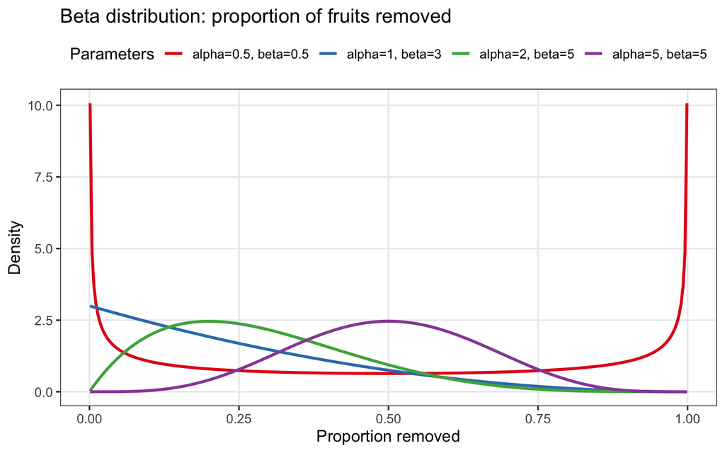

```r
# Example: proportion of fruits removed per site
alphas <- c(2, 5, 1, 0.5)
betas  <- c(5, 5, 3, 0.5)

x_beta <- seq(0.001, 0.999, length.out = 300)

df_beta <- purrr::map2_dfr(alphas, betas, function(a, b) {
  data.frame(
    x = x_beta,
    density = dbeta(x_beta, a, b),
    params = paste0("alpha=", a, ", beta=", b)
  )
})

p7 <- ggplot(df_beta, aes(x, density, color = params)) +
  geom_line(linewidth = 1.1) +
  scale_color_brewer(palette = "Set1") +
  labs(
    title = "Beta distribution: proportion of fruits removed",
    x = "Proportion removed",
    y = "Density",
    color = "Parameters"
  ) +
  theme(legend.position = "top")

p7
```

## 2.4 Comparative panel of distributions

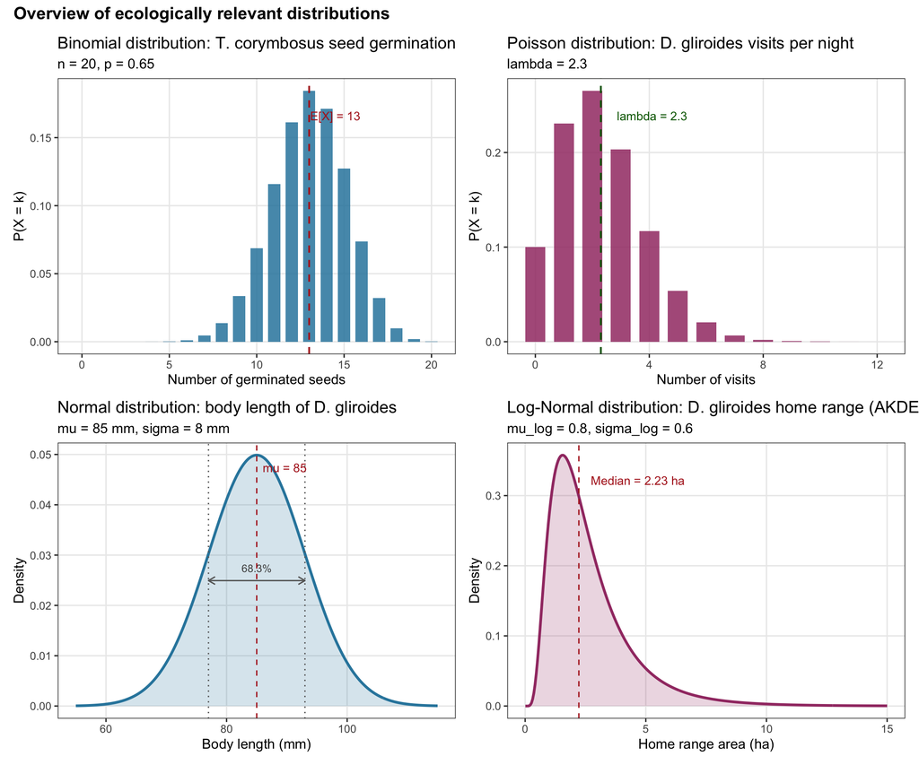

```r
(p1 + p2) / (p4 + p5) +
  plot_annotation(
    title = "Overview of ecologically relevant distributions",
    theme = theme(plot.title = element_text(size = 16, face = "bold"))
  )
```

## 2.5 How to choose the right distribution?

```r
dist_table <- data.frame(
  Distribution = c("Binomial", "Poisson", "Neg. Binomial",
                    "Normal", "Log-Normal", "Gamma", "Beta"),
  Type = c("Discrete", "Discrete", "Discrete",
           "Continuous", "Continuous", "Continuous", "Continuous"),
  Support = c("{0,...,n}", "{0,1,2,...}", "{0,1,2,...}",
              "(-Inf, +Inf)", "(0, +Inf)", "(0, +Inf)", "(0, 1)"),
  Ecological.use = c(
    "Presence/absence, germination, reproductive success",
    "Individual counts, rare events (equidispersion)",
    "Overdispersed counts (abundance, parasites)",
    "Morphometric measurements, symmetric continuous traits",
    "Biomass, area, population size, home range",
    "Waiting times, precipitation, concentrations",
    "Proportions, vegetation cover, removal rates"
  ),
  Mean.variance.relationship = c(
    "Var < mu (subdispersion possible)",
    "Var = mu",
    "Var > mu (overdispersion)",
    "Var independent of mu",
    "Var increases with mu",
    "Var increases with mu^2",
    "Var depends on alpha and beta"
  )
)

knitr::kable(dist_table, caption = "Guide for distribution selection")
```

Guide for distribution selection

| Distribution | Type | Support | Ecological.use | Mean.variance.relationship |
| --- | --- | --- | --- | --- |
| Binomial | Discrete | {0,…,n} | Presence/absence, germination, reproductive success | Var < mu (subdispersion possible) |
| Poisson | Discrete | {0,1,2,…} | Individual counts, rare events (equidispersion) | Var = mu |
| Neg. Binomial | Discrete | {0,1,2,…} | Overdispersed counts (abundance, parasites) | Var > mu (overdispersion) |
| Normal | Continuous | (-Inf, +Inf) | Morphometric measurements, symmetric continuous traits | Var independent of mu |
| Log-Normal | Continuous | (0, +Inf) | Biomass, area, population size, home range | Var increases with mu |
| Gamma | Continuous | (0, +Inf) | Waiting times, precipitation, concentrations | Var increases with mu^2 |
| Beta | Continuous | (0, 1) | Proportions, vegetation cover, removal rates | Var depends on alpha and beta |

# 3 Descriptive Statistics

Summary statistics are functions of sample data that condense key information about the underlying distribution. They are organized into three main families.

## 3.1 Measures of central tendency

```r
# Simulated data: body weight of D. gliroides (g)
# Two populations: native forest vs. plantation edge
set.seed(123)

weight_native <- rnorm(45, mean = 28, sd = 4.5)
weight_edge   <- c(rnorm(35, mean = 24, sd = 5), rnorm(10, mean = 38, sd = 3))

weight_data <- data.frame(
  weight = c(weight_native, weight_edge),
  habitat = rep(c("Native forest", "Plantation edge"),
                c(length(weight_native), length(weight_edge)))
)
```

### 3.1.1 Arithmetic mean, median, and mode

$$\bar{x} = \frac{1}{n}\sum_{i=1}^{n}
x_i$$

The **median** ($\tilde{x}$) is the value that splits the distribution into two equal halves. It is more robust to extreme values.

```r
summary_ct <- weight_data %>%
  group_by(habitat) %>%
  summarise(
    n = n(),
    mean = round(mean(weight), 2),
    median = round(median(weight), 2),
    trimmed_mean_10 = round(mean(weight, trim = 0.10), 2),
    .groups = "drop"
  )

knitr::kable(summary_ct,
             caption = "Measures of central tendency for D. gliroides body weight")
```

Measures of central tendency for D. gliroides body weight

| habitat | n | mean | median | trimmed_mean_10 |
| --- | --- | --- | --- | --- |
| Native forest | 45 | 28.30 | 28.32 | 28.24 |
| Plantation edge | 45 | 27.16 | 25.08 | 26.89 |

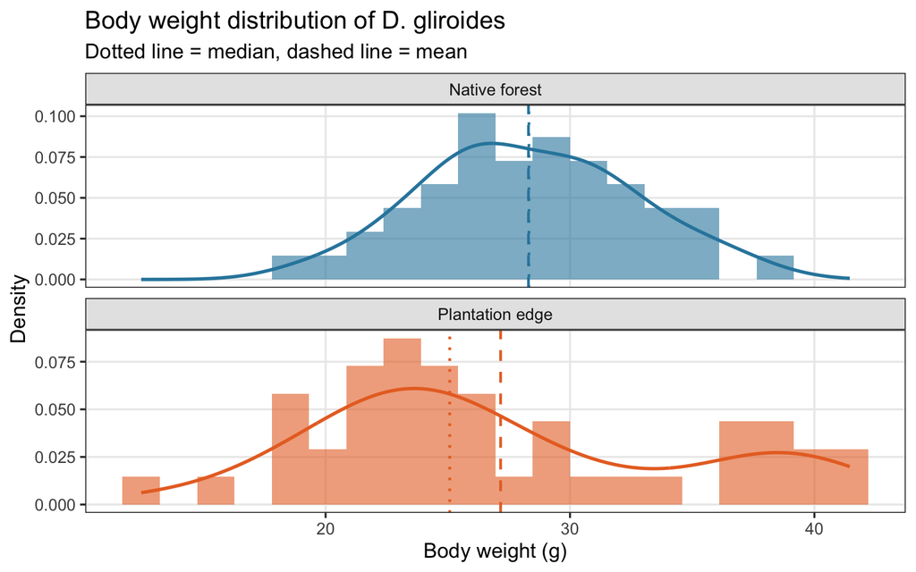

```r
ggplot(weight_data, aes(x = weight, fill = habitat)) +
  geom_histogram(aes(y = after_stat(density)),
                 bins = 20, alpha = 0.6, position = "identity") +
  geom_density(aes(color = habitat), linewidth = 1, fill = NA) +
  geom_vline(data = summary_ct,
             aes(xintercept = mean, color = habitat),
             linetype = "dashed", linewidth = 0.8) +
  geom_vline(data = summary_ct,
             aes(xintercept = median, color = habitat),
             linetype = "dotted", linewidth = 0.8) +
  scale_fill_manual(values = c("#2E86AB", "#E8702A")) +
  scale_color_manual(values = c("#2E86AB", "#E8702A")) +
  facet_wrap(~habitat, ncol = 1, scales = "free_y") +
  labs(
    title = "Body weight distribution of D. gliroides",
    subtitle = "Dotted line = median, dashed line = mean",
    x = "Body weight (g)",
    y = "Density"
  ) +
  theme(legend.position = "none")
```

> **Key point:** When mean != median, the distribution is asymmetric. The difference between the two indicates the degree and direction of skewness.

## 3.2 Measures of dispersion

### 3.2.1 Variance, standard deviation, and coefficient of variation

$$s^2 = \frac{1}{n-1}\sum_{i=1}^{n}(x_i -
\bar{x})^2, \quad s = \sqrt{s^2}, \quad CV = \frac{s}{\bar{x}} \times
100$$

### 3.2.2 Interquartile range (IQR) and MAD

The **IQR** = $Q_3 - Q_1$ and the **MAD** (median absolute deviation) are robust alternatives.

```r
summary_disp <- weight_data %>%
  group_by(habitat) %>%
  summarise(
    variance = round(var(weight), 2),
    SD = round(sd(weight), 2),
    CV_pct = round(sd(weight) / mean(weight) * 100, 1),
    IQR = round(IQR(weight), 2),
    MAD = round(mad(weight), 2),
    range = round(diff(range(weight)), 2),
    .groups = "drop"
  )

knitr::kable(summary_disp,
             caption = "Measures of dispersion for D. gliroides body weight")
```

Measures of dispersion for D. gliroides body weight

| habitat | variance | SD | CV_pct | IQR | MAD | range |
| --- | --- | --- | --- | --- | --- | --- |
| Native forest | 18.23 | 4.27 | 15.1 | 5.68 | 4.21 | 18.61 |
| Plantation edge | 56.79 | 7.54 | 27.8 | 9.60 | 5.85 | 28.99 |

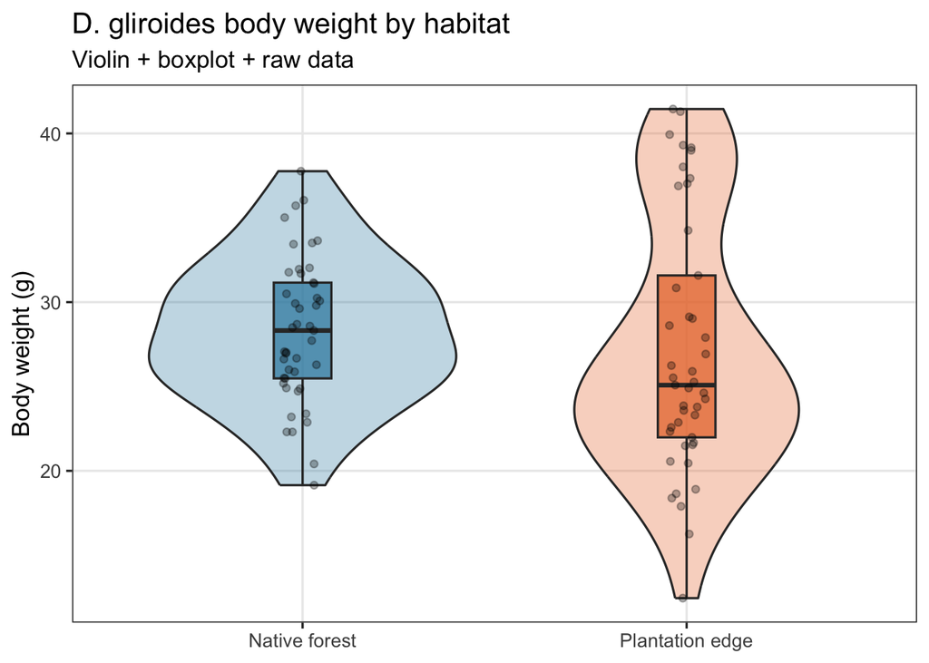

```r
ggplot(weight_data, aes(x = habitat, y = weight, fill = habitat)) +
  geom_violin(alpha = 0.3, width = 0.8) +
  geom_boxplot(width = 0.15, outlier.shape = 21,
               outlier.fill = "firebrick", alpha = 0.7) +
  geom_jitter(width = 0.05, alpha = 0.3, size = 1.5) +
  scale_fill_manual(values = c("#2E86AB", "#E8702A")) +
  labs(
    title = "D. gliroides body weight by habitat",
    subtitle = "Violin + boxplot + raw data",
    x = NULL, y = "Body weight (g)"
  ) +
  theme(legend.position = "none")
```

## 3.3 Measures of shape

### 3.3.1 Skewness

$$g_1 = \frac{n}{(n-1)(n-2)}
\sum_{i=1}^{n}\left(\frac{x_i - \bar{x}}{s}\right)^3$$

- $g_1 = 0$: symmetric
- $g_1 > 0$: right-tailed (positive skew)
- $g_1 < 0$: left-tailed (negative skew)

### 3.3.2 Kurtosis

$$g_2 = \frac{n(n+1)}{(n-1)(n-2)(n-3)}
\sum_{i=1}^{n}\left(\frac{x_i - \bar{x}}{s}\right)^4 -
\frac{3(n-1)^2}{(n-2)(n-3)}$$

- $g_2 = 0$: mesokurtic (like the normal)
- $g_2 > 0$: leptokurtic (heavy tails)
- $g_2 < 0$: platykurtic (light tails)

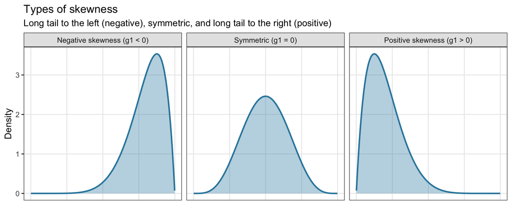

```r
# Illustrative figure of skewness using Beta distributions
# with parameters that produce clearly visible asymmetry
x_beta <- seq(0.001, 0.999, length.out = 500)

df_skew <- rbind(
  data.frame(x = x_beta, density = dbeta(x_beta, 8, 2),
             type = "Negative skewness (g1 < 0)"),
  data.frame(x = x_beta, density = dbeta(x_beta, 5, 5),
             type = "Symmetric (g1 = 0)"),
  data.frame(x = x_beta, density = dbeta(x_beta, 2, 8),
             type = "Positive skewness (g1 > 0)")
)

df_skew$type <- factor(df_skew$type,
                        levels = c("Negative skewness (g1 < 0)",
                                   "Symmetric (g1 = 0)",
                                   "Positive skewness (g1 > 0)"))

ggplot(df_skew, aes(x, density)) +
  geom_area(fill = "#2E86AB", alpha = 0.35) +
  geom_line(color = "#2E86AB", linewidth = 1) +
  facet_wrap(~type) +
  labs(
    title = "Types of skewness",
    subtitle = "Long tail to the left (negative), symmetric, and long tail to the right (positive)",
    x = NULL, y = "Density"
  ) +
  theme(axis.text.x = element_blank(), axis.ticks.x = element_blank())
```

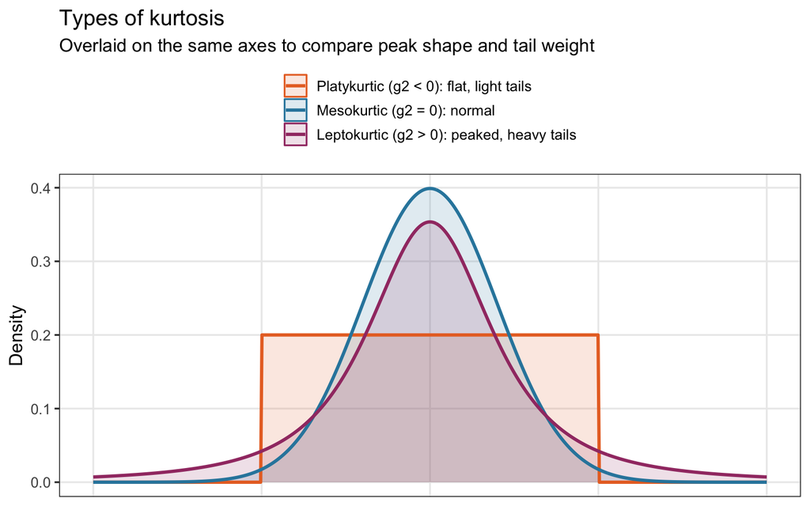

```r
# Illustrative figure of kurtosis: three curves OVERLAID
# to appreciate the difference in peak height and tail weight
x_seq <- seq(-5, 5, length.out = 500)

df_kurt <- rbind(
  data.frame(x = x_seq, density = dunif(x_seq, -2.5, 2.5),
             type = "Platykurtic (g2 < 0): flat, light tails"),
  data.frame(x = x_seq, density = dnorm(x_seq, 0, 1),
             type = "Mesokurtic (g2 = 0): normal"),
  data.frame(x = x_seq, density = dt(x_seq, df = 2),
             type = "Leptokurtic (g2 > 0): peaked, heavy tails")
)

df_kurt$type <- factor(df_kurt$type,
                        levels = c(
                          "Platykurtic (g2 < 0): flat, light tails",
                          "Mesokurtic (g2 = 0): normal",
                          "Leptokurtic (g2 > 0): peaked, heavy tails"))

ggplot(df_kurt, aes(x, density, color = type, fill = type)) +
  geom_area(alpha = 0.15, position = "identity") +
  geom_line(linewidth = 1.1) +
  scale_color_manual(values = c("#E8702A", "#2E86AB", "#A23B72")) +
  scale_fill_manual(values = c("#E8702A", "#2E86AB", "#A23B72")) +
  labs(
    title = "Types of kurtosis",
    subtitle = "Overlaid on the same axes to compare peak shape and tail weight",
    x = NULL, y = "Density", color = NULL, fill = NULL
  ) +
  theme(
    legend.position = "top",
    legend.direction = "vertical",
    axis.text.x = element_blank(),
    axis.ticks.x = element_blank()
  )
```

```r
summary_shape <- weight_data %>%
  group_by(habitat) %>%
  summarise(
    skewness = round(skewness(weight), 3),
    excess_kurtosis = round(kurtosis(weight) - 3, 3),
    .groups = "drop"
  )

knitr::kable(summary_shape,
             caption = "Shape measures for the weight distribution")
```

Shape measures for the weight distribution

| habitat | skewness | excess_kurtosis |
| --- | --- | --- |
| Native forest | 0.106 | -0.475 |
| Plantation edge | 0.474 | -0.763 |

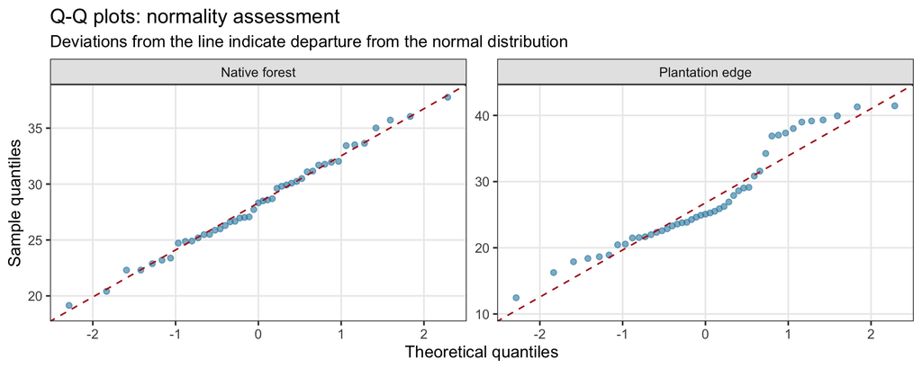

```r
ggplot(weight_data, aes(sample = weight)) +
  stat_qq(alpha = 0.6, color = "#2E86AB") +
  stat_qq_line(color = "firebrick", linetype = "dashed") +
  facet_wrap(~habitat, scales = "free") +
  labs(
    title = "Q-Q plots: normality assessment",
    subtitle = "Deviations from the line indicate departure from the normal distribution",
    x = "Theoretical quantiles",
    y = "Sample quantiles"
  )
```

## 3.4 Integrated visual summary

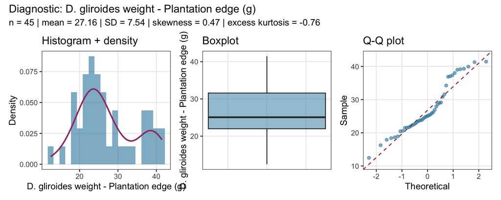

```r
# Quick diagnostic panel function
distribution_diagnostic <- function(x, varname = "Variable") {
  df <- data.frame(x = x)

  p_hist <- ggplot(df, aes(x)) +
    geom_histogram(aes(y = after_stat(density)),
                   bins = 20, fill = "#2E86AB", alpha = 0.6) +
    geom_density(color = "#A23B72", linewidth = 1) +
    labs(title = "Histogram + density", x = varname, y = "Density")

  p_box <- ggplot(df, aes(y = x)) +
    geom_boxplot(fill = "#2E86AB", alpha = 0.5, width = 0.3) +
    labs(title = "Boxplot", y = varname) +
    theme(axis.text.x = element_blank(), axis.ticks.x = element_blank())

  p_qq <- ggplot(df, aes(sample = x)) +
    stat_qq(color = "#2E86AB", alpha = 0.6) +
    stat_qq_line(color = "firebrick", linetype = "dashed") +
    labs(title = "Q-Q plot", x = "Theoretical", y = "Sample")

  p_hist + p_box + p_qq +
    plot_annotation(
      title = paste("Diagnostic:", varname),
      subtitle = paste0(
        "n = ", length(x),
        " | mean = ", round(mean(x), 2),
        " | SD = ", round(sd(x), 2),
        " | skewness = ", round(skewness(x), 2),
        " | excess kurtosis = ", round(kurtosis(x) - 3, 2)
      )
    )
}

distribution_diagnostic(weight_edge, "D. gliroides weight - Plantation edge (g)")
```

# 4 Central Limit Theorem and Convergence

## 4.1 Central Limit Theorem (CLT)

Let $X_1, X_2, \ldots, X_n$ be a random sample from a population with mean $\mu$ and finite variance $\sigma^2$. Then, as $n \rightarrow \infty$:

$$\bar{X}_n = \frac{1}{n}\sum_{i=1}^{n}
X_i \xrightarrow{d} \mathcal{N}\left(\mu,
\frac{\sigma^2}{n}\right)$$

Or equivalently:

$$Z_n = \frac{\bar{X}_n - \mu}{\sigma /
\sqrt{n}} \xrightarrow{d} \mathcal{N}(0, 1)$$

**This holds regardless of the shape of the original distribution**, as long as the variance is finite.

### 4.1.1 Visual demonstration

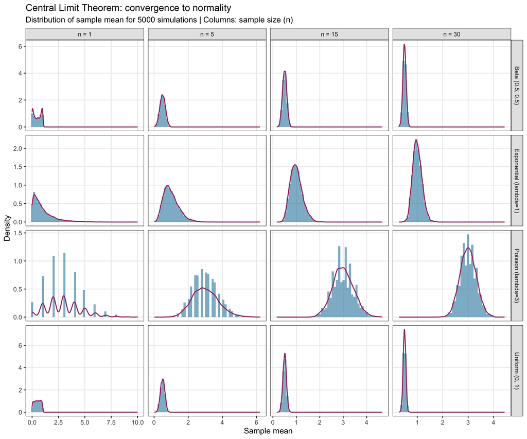

```r
# CLT demonstration with different source distributions
set.seed(2025)
n_sim <- 5000

# Source distributions
distributions <- list(
  "Exponential (lambda=1)" = function(n) rexp(n, rate = 1),
  "Uniform (0, 1)"         = function(n) runif(n, 0, 1),
  "Poisson (lambda=3)"     = function(n) rpois(n, lambda = 3),
  "Beta (0.5, 0.5)"        = function(n) rbeta(n, 0.5, 0.5)
)

sample_sizes <- c(1, 5, 15, 30)

# Simulation
clt_data <- purrr::map_dfr(names(distributions), function(dist_name) {
  rfun <- distributions[[dist_name]]
  purrr::map_dfr(sample_sizes, function(n) {
    means <- replicate(n_sim, mean(rfun(n)))
    data.frame(
      mean_val = means,
      n = paste0("n = ", n),
      distribution = dist_name
    )
  })
})

clt_data$n <- factor(clt_data$n,
                      levels = paste0("n = ", sample_sizes))

ggplot(clt_data, aes(x = mean_val)) +
  geom_histogram(aes(y = after_stat(density)),
                 bins = 50, fill = "#2E86AB", alpha = 0.6) +
  geom_density(color = "#A23B72", linewidth = 0.8) +
  facet_grid(distribution ~ n, scales = "free") +
  labs(
    title = "Central Limit Theorem: convergence to normality",
    subtitle = paste0(
      "Distribution of sample mean for ", n_sim,
      " simulations | Columns: sample size (n)"
    ),
    x = "Sample mean",
    y = "Density"
  ) +
  theme(strip.text = element_text(size = 10))
```

> **Key observation:** With $n = 30$, the distribution of $\bar{X}$ is practically normal even when the source distribution is strongly skewed (Exponential) or bimodal (Beta with parameters < 1). However, for very skewed distributions, $n > 30$ may be needed.

### 4.1.2 Implications for ecology

```r
# Practical example: estimating pollinator richness
# Source distribution: Poisson with lambda = 8 species per site

lambda_rich <- 8
sample_sizes_eco <- c(3, 5, 10, 20, 50)

clt_richness <- purrr::map_dfr(sample_sizes_eco, function(n) {
  means <- replicate(10000, mean(rpois(n, lambda_rich)))
  data.frame(
    mean_val = means,
    n = n,
    se_theoretical = sqrt(lambda_rich / n),
    se_observed = sd(means)
  )
})

# Compare theoretical vs observed standard error
se_comp <- clt_richness %>%
  group_by(n) %>%
  summarise(
    se_theoretical = first(se_theoretical),
    se_simulated = sd(mean_val),
    .groups = "drop"
  ) %>%
  mutate(across(starts_with("se"), ~round(.x, 4)))

knitr::kable(se_comp,
             caption = "Theoretical standard error (sigma/sqrt(n)) vs. simulated")
```

Theoretical standard error (sigma/sqrt(n)) vs. simulated

| n | se_theoretical | se_simulated |
| --- | --- | --- |
| 3 | 1.6330 | 1.6294 |
| 5 | 1.2649 | 1.2577 |
| 10 | 0.8944 | 0.8905 |
| 20 | 0.6325 | 0.6314 |
| 50 | 0.4000 | 0.4030 |

## 4.2 Types of convergence

It is important to distinguish the different modes of convergence in probability:

### 4.2.1 1. Convergence in distribution ($\xrightarrow{d}$)

$$F_{X_n}(x) \rightarrow F_X(x) \text{ for
all } x \text{ where } F_X \text{ is continuous}$$

This is the weakest mode. The CLT is a canonical example.

### 4.2.2 2. Convergence in probability ($\xrightarrow{P}$)

$$P(|X_n - X| > \epsilon) \rightarrow 0
\text{ for all } \epsilon > 0$$

The **Weak Law of Large Numbers**: $\bar{X}_n \xrightarrow{P} \mu$.

### 4.2.3 3. Almost sure convergence ($\xrightarrow{a.s.}$)

$$P\left(\lim_{n \rightarrow \infty} X_n =
X\right) = 1$$

The **Strong Law of Large Numbers**: $\bar{X}_n \xrightarrow{a.s.} \mu$.

### 4.2.4 Relationship between convergence types

$$\text{a.s.} \Rightarrow \text{in
probability} \Rightarrow \text{in distribution}$$

(The reverse implications do not hold in general.)

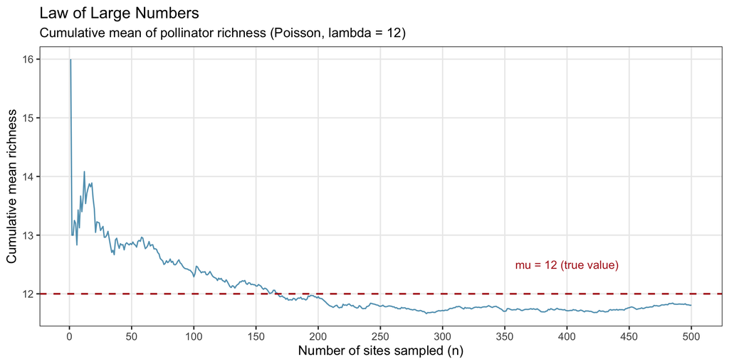

```r
# Visualization of the Law of Large Numbers
set.seed(42)

# Cumulative sampling of species richness
# True distribution: Poisson(lambda = 12)
n_max <- 500
x_lln <- rpois(n_max, lambda = 12)

cumul_mean <- cumsum(x_lln) / seq_along(x_lln)

df_lln <- data.frame(
  n = 1:n_max,
  cumulative_mean = cumul_mean
)

ggplot(df_lln, aes(n, cumulative_mean)) +
  geom_line(color = "#2E86AB", alpha = 0.8) +
  geom_hline(yintercept = 12, linetype = "dashed",
             color = "firebrick", linewidth = 0.8) +
  annotate("text", x = n_max * 0.8, y = 12.5,
           label = "mu = 12 (true value)",
           color = "firebrick", size = 4) +
  labs(
    title = "Law of Large Numbers",
    subtitle = "Cumulative mean of pollinator richness (Poisson, lambda = 12)",
    x = "Number of sites sampled (n)",
    y = "Cumulative mean richness"
  ) +
  scale_x_continuous(breaks = seq(0, 500, 50))
```

## 4.3 Standard error and sample size

The **standard error** of the mean decreases with $\sqrt{n}$:

$$SE(\bar{X}) =
\frac{\sigma}{\sqrt{n}}$$

This has direct implications for ecological sampling design.

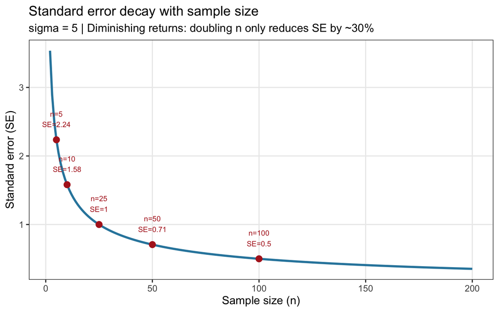

```r
sigma_example <- 5
n_vals <- 2:200

df_se <- data.frame(
  n = n_vals,
  SE = sigma_example / sqrt(n_vals)
)

# Reference lines for key reductions
n_refs <- c(5, 10, 25, 50, 100)

ggplot(df_se, aes(n, SE)) +
  geom_line(color = "#2E86AB", linewidth = 1.2) +
  geom_point(data = df_se %>% filter(n %in% n_refs),
             color = "firebrick", size = 3) +
  geom_text(data = df_se %>% filter(n %in% n_refs),
            aes(label = paste0("n=", n, "\nSE=", round(SE, 2))),
            vjust = -0.8, size = 3, color = "firebrick") +
  labs(
    title = "Standard error decay with sample size",
    subtitle = paste0("sigma = ", sigma_example,
                      " | Diminishing returns: ",
                      "doubling n only reduces SE by ~30%"),
    x = "Sample size (n)",
    y = "Standard error (SE)"
  )
```

> **Practical advice:** Increasing sample size from 25 to 100 (4x) only cuts the SE in half. In ecological sampling designs, it is often more efficient to invest in stratification or in reducing within-unit variability than in simply increasing $n$.

# 5 Proposed Exercises

## 5.1 Exercise 1: Conditional probability and Bayes

In a pollination study in the blooming desert, it is known that:

- 60% of floral visits are from native bees and 40% from *Apis mellifera*.
- The probability of effective pollination given a visit by a native bee is 0.75.
- The probability of effective pollination given a visit by *Apis* is 0.30.
1. What is the probability that any given visit results in effective pollination?
2. If we observe effective pollination, what is the probability that the visitor was a native bee?

## 5.2 Exercise 2: Distribution selection

You have the following ecological datasets. For each one, justify which distribution you would use and why:

1. Number of parasites per host (mean = 3.2, variance = 18.7).
2. Proportion of vegetation cover per quadrat (values between 0 and 1).
3. Leaf dry biomass (g) of plants from the same species.
4. Presence/absence of *D. gliroides* in 50 camera traps during one night.

## 5.3 Exercise 3: Summary statistics and diagnostics

Load an ecological dataset of your choice and apply the `distribution_diagnostic()` function defined in this lesson. Interpret the results in terms of:

- Is the mean an appropriate measure of central tendency?
- Which measure of dispersion is most informative?
- Which theoretical distribution would provide the best fit?

## 5.4 Exercise 4: CLT in action

Simulate 10,000 sample means of size $n = 5, 10, 30, 100$ from a Negative Binomial distribution with $\mu = 4$ and $\theta = 0.8$ (strongly overdispersed). At what $n$ does the distribution of $\bar{X}$ reasonably approximate a normal?

# 6 Recommended Readings

- **Bolker, B.M.** (2008). *Ecological Models and Data in R*. Princeton University Press. Chapters 4-5.
- **Gotelli, N.J. & Ellison, A.M.** (2013). *A Primer of Ecological Statistics*. 2nd ed. Sinauer. Chapters 2-4.
- **Casella, G. & Berger, R.L.** (2002). *Statistical Inference*. 2nd ed. Duxbury. Chapters 1-5 (for deeper theory).